# Analysing the Revenue per attendant of shows on Broadway

Julianna Szabo

03/01/2021

# Executive summary

This project aims to explore some of the main factors influencing the Revenue per attendants of shows on Broadway in New York City. It uses four exploratory variables. Occupancy percentage, Percentage of potential revenue, Number of performances, and the Show type. Using a linear model including all these variables, the conclusion is that the Percentage of potential revenue and the Show type Plays are statistically significant to Revenue per attendant, while the other three are most likely affecting the dependent variable, but cannot be prover to do so in this analysis. Overall, the model is significant and a better representation than one with no independent variables. This model can be generalised to other cities with similar theater scenes. Further, there are some other variables that have not been consisted in this analysis, that could prove to also affect the Revenue per attendant, since this model only explains 40% of the observations.

# Introduction

This report aims to examine the main factors influencing the Revenue per attendant of a show on Broadway. Looking at the data, it is predicted that the main influencing variable would be the occupancy percentage, but the other interesting variables in the data could also affect the dependent variable. This project has great benefit for people involved in the theatre industry to see how different elements affect their revenue and possible in the end profit.

The main research question of this report will be:  
What are some of the essential variables that affect the revenue per attendant of shows on Broadway?

# Data

The data comes from the CORGIS Dataset Project and was originally published by the Broadway League. You can find a link to the original file in my GitHub folder. The data is a cross sectional time series covering all the shows that have been on Broadway from 1990 to 2016. For this project, the cross sectional aspect is the more important, and therefore, the data was aggregated based on show name. The time series aspect has been discarded but there have been a few adjustments made to control the effects it has on the data.  
One of the main ones is using Revenue per attendant as the dependent variable. Since there are shows that ran for over 25 years and some for less than a year it would be unfair to compare the total revenue per show during its runtime. However, since the data includes the total revenue and the total number of attendants over the whole runtime of the show, using the ratio of these two variable gives an easy comparable relevant variable.  
Overall the quality of the data is good. It included over 3000 observations originally after the aggregation to cross sectional data, which, after cleaning, resulted in 758 complete observations. This shows a very representative sample, that has the potential of generalisation to other cities such as London with a similar theatre scene. There have been a few discrepancies in the data especially with the variables representing percentages. For both Occupancy percentage and Percentage of potential revenue, there were observations with values over 100%, which have been dropped.  
Measurement errors are another thing to consider. Classic error measurement is possible in the dependent variable mainly because of counting the number of attendants. This number does not come from a computer system, but is the actual number of people entering the theater, which could be miscounted by the doorman.If this was the case, the slope would still be similar to what is given. Number of shows are least likely to have error, since this is standard weekly, which was then agregated in the cleaning process. The other explanatory variables that are quantitative could include measurement errors since they depend on numbers that are entered by people. If this is the case, the slope would change with values that do not have error. Looking at the data more in detail, one can see that there are four explanatory variables to consider for one dependent variable.

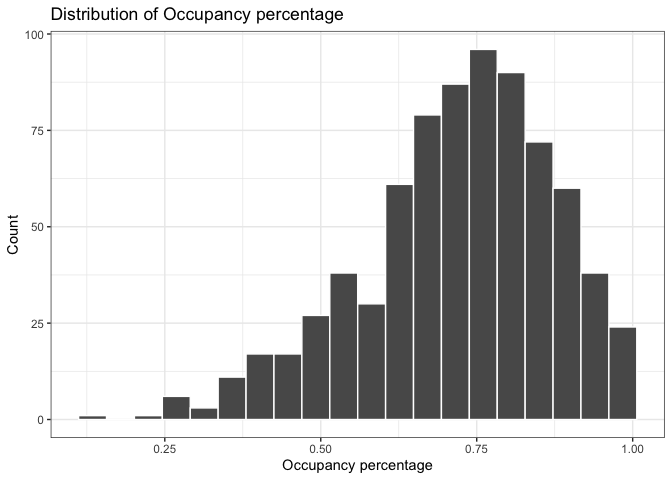

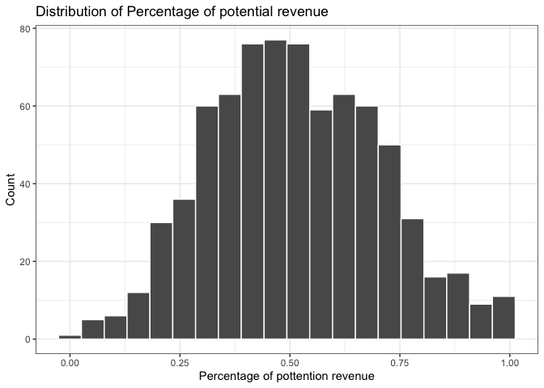

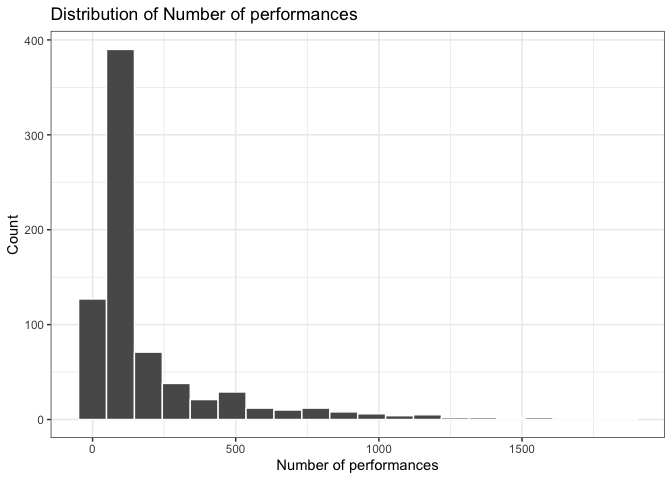

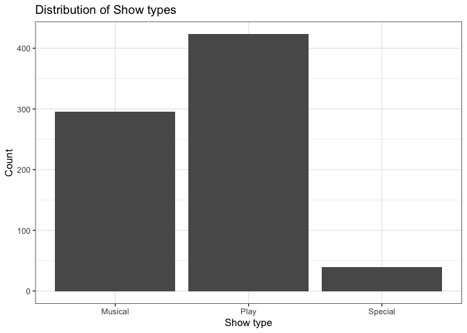

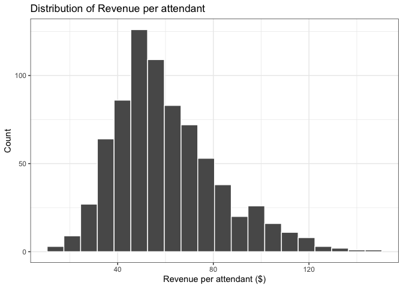

( The decision was made to crop the Distribution for Number of performances to 2000 max to show a clearer distribution of the values between 0 and 1000. This distribution would not be very visible if some of the extreme values would have also been shown. These extreme values will, however, be kept in the distribution for analysis, since they are not errors)

| variable | type | n | mean | median | min | max | sd |
| --- | --- | --- | --- | --- | --- | --- | --- |
| Occupancy percentage | x | 758 | 0.72 | 0.74 | 0.15 | 1.00 | 0.15 |
| Percentage of possible revenue | x | 758 | 0.51 | 0.50 | 0.01 | 1.00 | 0.19 |
| Number of performances | x | 758 | 279.96 | 99.00 | 0.00 | 8400.00 | 721.28 |
| Revenue per attendant | y | 758 | 60.48 | 56.10 | 12.64 | 145.64 | 21.80 |

As shown in the graphs above, there are four quantitative ordered variables (including the dependent variable) and one qualitative nominal variable. All quantitative variables, with the exception of the Number of shows, are distributed somewhat normally with a left or right tail. The summary table of the variables also show the distribution of the values, where the only one that stand out is that there is a show with 0 performances. This is an error, which is surprising for this variable. However, after checking the source data, it looks like there was only one week of performances, so it will be resolved due to some transformations later on. Further, none of the variables are highly correlated (see Appendix 1), so the analysis can be conducted without eliminating any variable.  
After seeing the distribution of the variables, the decision was made to do transformations on some of the quantitative variables. After examining grams with possible log transformations (see Appendix 2), log transformations were applied to the Number of performances and Revenue per attendant. This was decided based on the distribution of the observations, but also due to the interpretation being more cohesive across variables. One additional transformation that was later added was to instead of a log transformation of Number of performances a dummy variable was created where 0 denotes the shows with less than one year (416) of performances while 1 denotes the ones with more than that.

# Model

To create a more robust model, the dataset has been split into train and test sets. The model exploration was done on train dataset, and then model picked was rerun and tested on the test set. I will also be working with a 95% confidence interval for all the values from now.
After examining the different options for models (see Appendix 3 and Model comparison file in Out folder), the best fitting model is the linear model using all four explanatory variables. The formula of this model is shown here:
$$\begin{aligned}
\text{ln(Revenue/attendant)} = {β_0} + {β_1}\text {Occupancy percentage} + {β_2}\text
{ Percentage of possible revenue} \\
+ {β_3}\text { Number of performances} + {β_4}\text{ Plays (Show type) } \\
+ {β_5}\text{ Specials (Show type) }
\end{aligned}$$

|  | Estimate | Std. Error | t value | Pr(>\|t\|) | CI Lower | CI Upper | DF |
| --- | --- | --- | --- | --- | --- | --- | --- |
| (Intercept) | 3.44 | 0.06 | 57.88 | 0.00 | 3.33 | 3.56 | 600 |
| occupancy_percentage | 0.23 | 0.12 | 1.90 | 0.06 | -0.01 | 0.46 | 600 |
| percentage_of_poss_revenue | 0.97 | 0.10 | 9.76 | 0.00 | 0.77 | 1.16 | 600 |
| as.factor(num_of_performances_d)1 | 0.02 | 0.03 | 0.78 | 0.44 | -0.04 | 0.09 | 600 |
| as.factor(show_type)Play | -0.11 | 0.02 | -4.48 | 0.00 | -0.16 | -0.06 | 600 |
| as.factor(show_type)Special | -0.08 | 0.08 | -1.10 | 0.27 | -0.23 | 0.07 | 600 |

### Interpretation of coefficients:

Beta 0: When all explanatory variables are 0, the Revenue per attendant would be ln(3.44) - this is almost meaningless. Beta 1: the Revenue per attendant increases by approximately 23% on average for every additional percentage of occupancy of the theatre for Musicals running for less than one year with same percentage of potential profit. Beta 2: the Revenue per attendant increases by approximately 97% on average for every additional percentage of the possible revenue achieved for Musicals running for less than one year with the same occupancy percentage Beta 3: When the runtime is longer than one year, the Revenue per attendant increased by approximated 2% on average for Musicals where occupancy percentage and percentage of potential revenue is the same Beta 4: If a show is a Play instead of a Musical, on average the Revenue per attendant is 11% lower on average, when all other variables are the same. Beta 5: If a show is a Special instead of a Musical, on average the Revenue per attendant is 8% lower average, when all other variables are the same.

Even with this model, that fits the data the best, it still only explains 41% of the observations. Further, about half of the betas have a very low p value and can therefore we considered very good approximations for this dataset, while three values (Occupancy percentage, Number of performances, and Special show type) have a high p value and therefore the real slope value will fall outside of the 95% confidence interval. Looking at the previous models, it is clear that the real slope of the Occupancy percentage is probably closer to 1 (or 100%), while the Number of performances is most likely closer to 0.1 (or 10%).

|  | Train - Estimates | Test - Estimates |
| --- | --- | --- |
| Intercept | 3.44 | 3.41 |
| Occupancy Percentage | 0.23 | 0.23 |
| Percentage of potential revenue | 0.97 | 1.00 |
| More than one year of performances | 0.02 | 0.02 |
| Show type is Play | -0.11 | -0.10 |
| Show type is Special | -0.08 | -0.08 |

The model shown is very robust based on the train and test robustness check run. As can be seen in the table above the model gives almost the same coefficients when it is rerun of the test sample. While the R squared here is only 38% but it is very close to the 41% of the original train model.

# Generalization

This project has used data from shows on Broadway in New York City to analyze the different variables affecting the Revenue per attendant in theater. From the findings, generalizations can be made for overall theater industry, especially in cities like London or Hamburg which have a similarly large theater scene within the city. It can be inferred that Plays bring less Revenue per attendant compared to Musicals, and that increasing the percentage of potential revenue made increases the revenue per attendant. Further, the f statistic shows that the model does fit the data better than one with no independent variables, which gives the model some credibility especially for generalization. The model also works for more general unknown pattern, however only the parts that are statistically significant.

In terms of causality, it cannot be proven statistically that they are. However, looking at the values and thinking logically it is clear how Percentage of potential revenue could be somewhat causal. The the higher this is the higher the revenue is which is the numerator of the dependent variable. Further, Occupancy percentage could also lead to higher revenue, but also higher number of attendants. It could affect either or both, so the effect is not predictable. Thinking of omitted variables, show rating could be an important factor. If shows have higher ratings, there would be more people trying to buy tickets. Therefore, the shows could charge more for their tickets. Another variable that could be important would be if they sell day -, standing-, or lottery tickets. These are tickets sold the day of the show at a very cheap price that could affect the Revenue per attendant.

# Summary

Overall, this project demonstrates that all four exploratory variables (Occupancy percentage of the theater, Percentage of potential profit, the total Number of performances, and the Show type) have some impact on Revenue per attendant. It can be said with confidence that overall Musicals have a higher Revenue per attendant than Plays, and potentially Specials. Further, larger occupancy and larger percentage of potential revenue reached, generally lead to higher Revenue per attendant. The Number of shows has a small affect on the dependent variable. However, since the model only covers approximately 40% of the observations, this is not conclusive, since there are many observations that cannot be explained by this model.

# Appendix 1 - Correlation

| Var1 | Var2 | corr_val |
| --- | --- | --- |
| ln_occupancy_percentage | occupancy_percentage | 0.98 |
| ln_percentage_of_poss_revenue | percentage_of_poss_revenue | 0.93 |
| ln_revenue_per_att | revenue_per_att | 0.97 |
| occupancy_percentage | ln_occupancy_percentage | 0.98 |
| revenue_per_att | ln_revenue_per_att | 0.97 |
| percentage_of_poss_revenue | ln_percentage_of_poss_revenue | 0.93 |

# Appendix 2 - Ln transformation

## Occupancy percentage

### Level - level regression

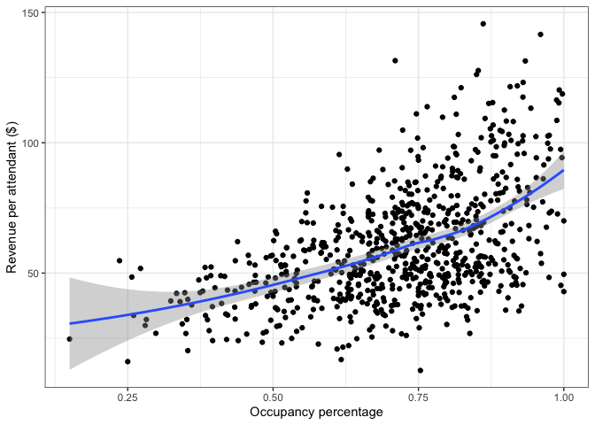

### Log - level regression

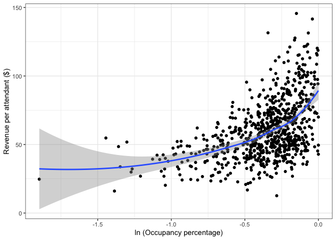

### Level - log regression

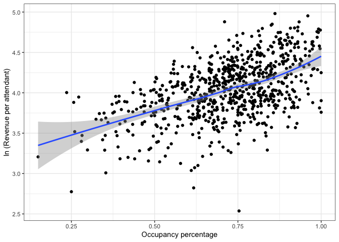

### Log - log regression

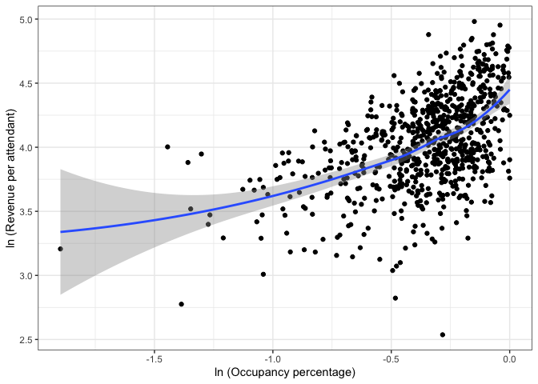

## Percentage of potential profit

### Level - level regression

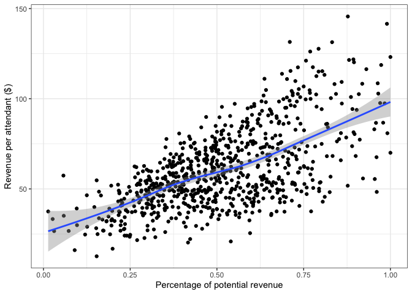

### Log - level regression

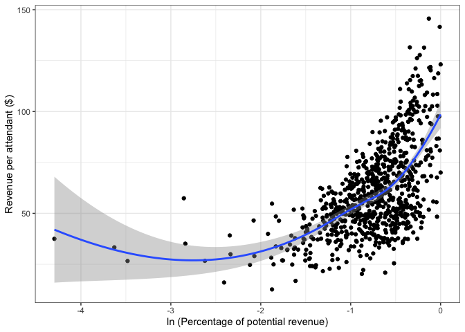

### Level - log regression

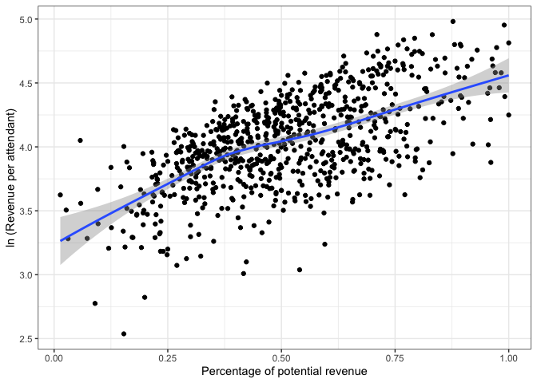

### Log - log regression

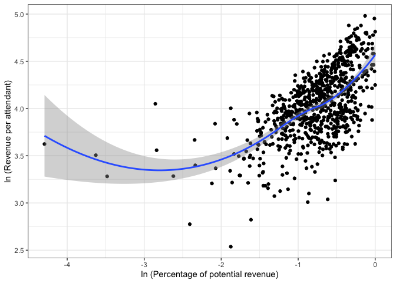

## Number of performances

### Level - level regression

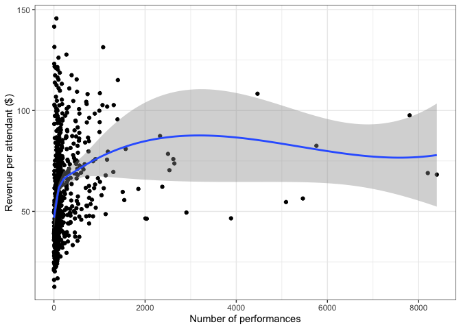

### Log - level regression

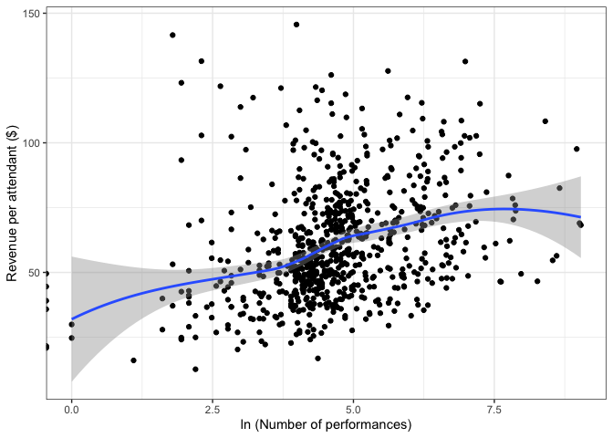

### Level - log regression

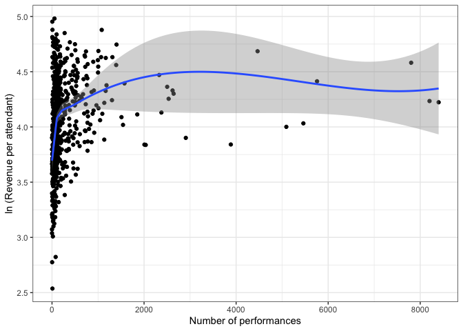

### Log - log regression

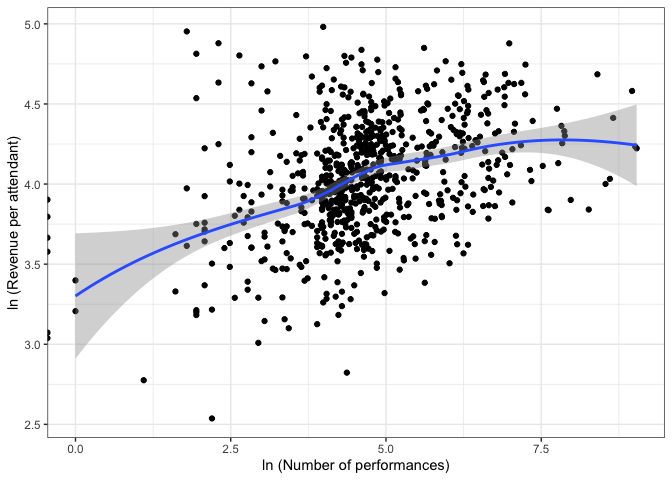

# Appendix 3 - Regression modes

To make my regression model more robust, I created a train and test data set

## Regression 1 - Simple linear regression

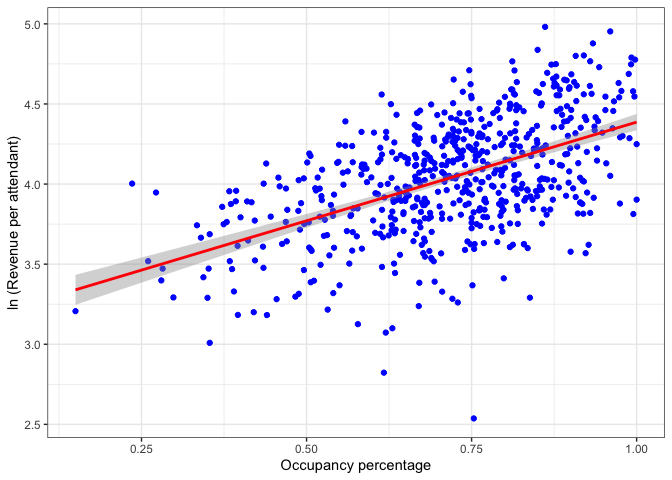

## Regression 2 - Quadratic (linear) regression

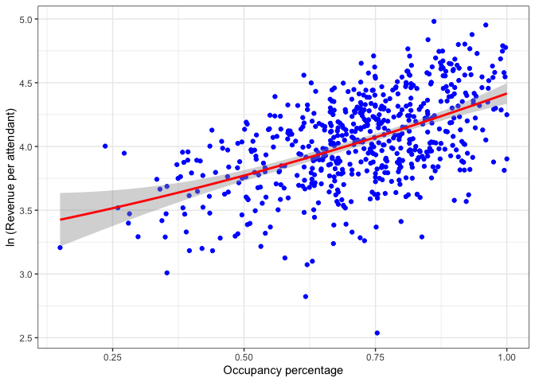

## Regressipn 3 - Piecewise linear spline regression

Using 0.5 as a cutof point

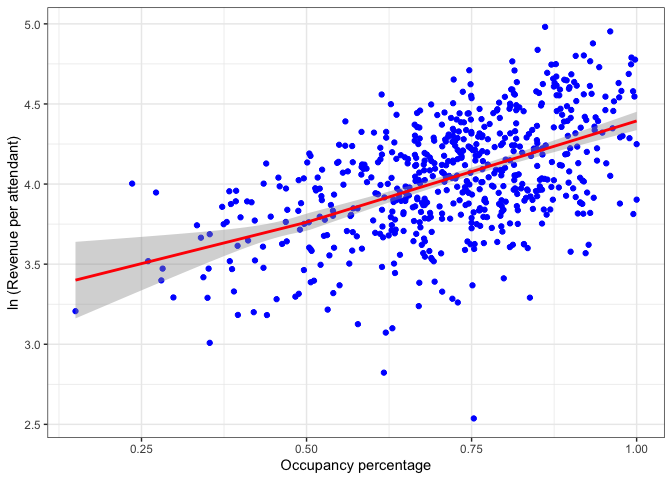

## Regression 4 - Weighted linear regression, where weights = percentage of total revenue

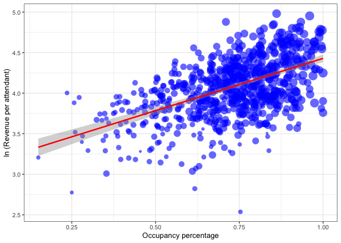

## Regression 5 - Weighted linear regression, where weights = number of performances

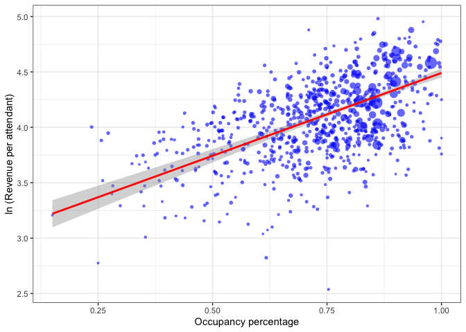

## Model Comparison

|  | reg1 | reg2 | reg3 | reg4 | reg5 |
| --- | --- | --- | --- | --- | --- |
| (Intercept) | 3.15 *** | 3.30 *** | 3.25 *** | 3.14 *** | 3.00 *** |
|  | (0.06) | (0.17) | (0.17) | (0.06) | (0.11) |
| occupancy_percentage | 1.23 *** | 0.76 |  | 1.29 *** | 1.49 *** |
|  | (0.08) | (0.51) |  | (0.09) | (0.15) |
| occupancy_percentage_sq |  | 0.35 |  |  |  |
|  |  | (0.38) |  |  |  |
| lspline(occupancy_percentage, 0.5)1 |  |  | 1.03 ** |  |  |
|  |  |  | (0.36) |  |  |
| lspline(occupancy_percentage, 0.5)2 |  |  | 1.27 *** |  |  |
|  |  |  | (0.10) |  |  |
| nobs | 606 | 606 | 606 | 606 | 606 |
| r.squared | 0.28 | 0.28 | 0.28 | 0.27 | 0.30 |
| adj.r.squared | 0.28 | 0.28 | 0.28 | 0.27 | 0.30 |
| statistic | 247.95 | 123.86 | 123.39 | 218.79 | 98.76 |
| p.value | 0.00 | 0.00 | 0.00 | 0.00 | 0.00 |
| df.residual | 604.00 | 603.00 | 603.00 | 604.00 | 604.00 |
| nobs.1 | 606.00 | 606.00 | 606.00 | 606.00 | 606.00 |
| se_type | HC2.00 | HC2.00 | HC2.00 | HC2.00 | HC2.00 |
| *** p < 0.001; ** p < 0.01; * p < 0.05. |  |  |  |  |  |

Looks like these models with mainly one variable are not a great fit for the data. Therefore, I will include additional variables to try and get a better fit. Further, it looks like the original use of “Number of Performances” has no impact so I will try and create a dummy variable and use that instead. I will use 0 for any show that had less than one year of performances so less than 8*52 (416) and one for those that have had more.

## Additional models

Check if it becomes better if one of the weights are included as variables. I will also be testing model number 9 (which is the best fit) against the test data set

|  | reg6 | reg7 | reg8 | reg9 | reg_test |
| --- | --- | --- | --- | --- | --- |
| (Intercept) | 3.33 *** | 3.19 *** | 3.35 *** | 3.44 *** | 3.41 *** |
|  | (0.06) | (0.06) | (0.06) | (0.06) | (0.13) |
| occupancy_percentage | 0.30 * | 1.15 *** | 0.27 * | 0.23 | 0.23 |
|  | (0.12) | (0.08) | (0.12) | (0.12) | (0.21) |
| percentage_of_poss_revenue | 0.97 *** |  | 0.94 *** | 0.97 *** | 1.00 *** |
|  | (0.10) |  | (0.10) | (0.10) | (0.16) |
| as.factor(num_of_performances_d)1 |  | 0.12 *** | 0.09 ** | 0.02 | 0.02 |
|  |  | (0.03) | (0.03) | (0.03) | (0.07) |
| as.factor(show_type)Play |  |  |  | -0.11 *** | -0.10 |
|  |  |  |  | (0.02) | (0.05) |
| as.factor(show_type)Special |  |  |  | -0.08 | -0.08 |
|  |  |  |  | (0.08) | (0.16) |
| nobs | 606 | 606 | 606 | 606 | 152 |
| r.squared | 0.39 | 0.29 | 0.40 | 0.41 | 0.38 |
| adj.r.squared | 0.39 | 0.29 | 0.39 | 0.41 | 0.36 |
| statistic | 180.94 | 141.00 | 130.64 | 85.85 | 22.08 |
| p.value | 0.00 | 0.00 | 0.00 | 0.00 | 0.00 |
| df.residual | 603.00 | 603.00 | 602.00 | 600.00 | 146.00 |
| nobs.1 | 606.00 | 606.00 | 606.00 | 606.00 | 152.00 |
| se_type | HC2.00 | HC2.00 | HC2.00 | HC2.00 | HC2.00 |
| *** p < 0.001; ** p < 0.01; * p < 0.05. |  |  |  |  |  |